# Text Reminders and FIT Kit Returns

A Three-Window Bayesian Hierarchical Model: Design, Changes and Results

November 23, 2026

Between 2019 and 2023, the clinic dispensed **4,302 FIT kits** to **2,092 patients**. In January 2022 it started texting patients whose kits were still out at day 14, every 2 weeks until day 90. Over the same period, the share of kits returned rose from 77.6% to 83.7%.

How much of that rise came from the text reminders, and how much would have happened anyway?

**Key Findings**

- **Reminders raised the return rate by about 7.2 points.**
  - With reminders, 83.7% of 2022–2023 kits were returned.
  - Without them (same kits, same patients), the model estimates 76.5%.
  - The gain is 7.2 points, 95% CrI [4.5, 10.1]. P(Any Benefit) > 99% and P(Return Rate Impact > 5%) = 95%.
  - At the clinic’s 2022–2023 volume of about 1,280 kits a year, that is about 93 more completed screening tests each year, 95% CrI [58, 129].
- **The gain only shows up once reminders start.**
  - Returned by day 14, before any text: 43.9% before 2022 and 43.0% after.
  - Returned in days 15–90, of kits still out at day 14: 53.7% → 63.0%.
  - Returned after day 90, of kits still out at day 90: 13.5% → 22.6%.
- **Patients who declined texts saw little gain.** Decliners gained 0.7 points, 95% CrI [-5.0, 6.4]; consenters gained 7.6 points, 95% CrI [4.8, 10.4]. The probability that consenters gained more is 99%.
- **Subgroups.**
  - Women gained 8.2 points and men 6.0 (probability women gained more: 98%).
  - On the log-odds scale, the reminder effect changed per decade of age by $\gamma_{\text{age}}$ = 0.20, 95% CrI [-0.01, 0.43] (probability it grows with age: 97%).
  - Other subgroup differences were small and uncertain.

# 1 Why a New Model

What was wrong with the original model, and what did the reviewers ask for?

The original analysis (OMED 2025 poster) used a Bayesian hierarchical binomial model. Peer review raised 5 concerns it did not resolve:

1. **Repeated kits from the same patient.** 78% of kits come from patients who received more than 1 kit, and these patients tend to return all of their kits or none. The original model had random effects for demographic groups but no patient-level effect, so it treated every kit as independent.
2. **Cohort differences.** The pre and post cohorts differ in age, prior screening and language.
3. **Inconsistent numbers** between the poster and the manuscript.
4. **Exposure.** Texts only went to kits still out at day 14, every 2 weeks until day 90. Many post-period kits came back before any text was sent.
5. **Subgroup claims** about age, sex and language, made without analyses that test them.

I rebuilt the model from the cleaned data to address each of these. The full list of changes is in Changes from the Original Model.

# 2 Data

The analysis uses **4,302 FIT kits** dispensed to **2,092 patients** between January 2019 and December 2023:

- 1,742 kits before reminders began (2019–2021)
- 2,560 kits after (2022–2023)

Data cleaning is documented separately in the audit log and EDA report.

**Outcome.** A kit counts as returned if it came back at any point before the data were pulled. The latest return in the file is June 05, 2024, so every kit had at least 5 months to come back.

**Kits per patient.** The reviewer asked how common repeated kits are. 55% of patients received more than 1 kit, which is why the model needs a patient-level effect:

| Kits received | Patients | % of patients |
| --- | --- | --- |
| 1 | 944 | 45.1% |
| 2 | 518 | 24.8% |
| 3 | 332 | 15.9% |
| 4 | 192 | 9.2% |
| 5 | 85 | 4.1% |
| 6+ | 21 | 1.0% |

# 3 The Model

## 3.1 Three-Window Design

How can the reminder effect be separated from everything else that changed in 2022?

In the post period, the clinic texted patients every 2 weeks from day 14 to day 90 after a kit was dispensed. Texts stopped as soon as the kit came back, and stopped for good at day 90. As such, a reminder could only have influenced a kit still out at day 14, and mainly during days 15–90.

My first version split each kit into 2 windows: returned by day 14, and returned at any point after. Once the clinic confirmed that texts stopped at day 90, I split the second window in two so the model matches the actual schedule:

- **Window 1 (days 0–14):** was the kit returned by day 14? No kit had received a text yet, before or after 2022. Any change here after 2022 comes from something other than the reminders.
- **Window 2 (days 15–90):** for kits still out at day 14, was the kit returned by day 90? This is where the texts were sent.
- **Window 3 (day 91+):** for kits still out at day 90, was the kit ever returned? Texts had stopped. A separate term captures any post-2022 change here, such as late responses to the final texts.

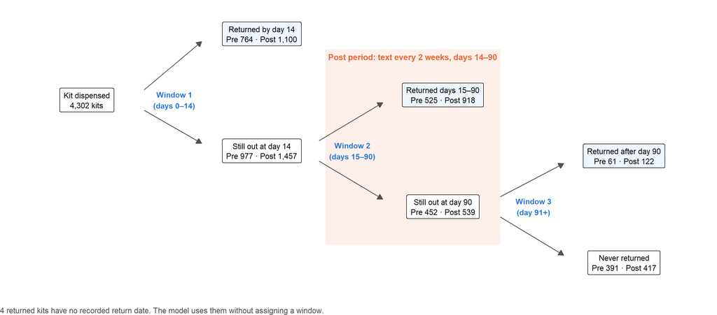

**Why the windows help.** Reminders could only act in window 2, while most other changes (staffing, kit type, patient mix) would affect every window. Comparing the post-2022 change in window 2 with the change in window 1 separates the reminder effect from everything else that changed in 2022. The first 14 days work like a control group built into the timeline.

**Key assumption.** Without reminders, the post-2022 changes would have shifted returns in each window by the same amount on the odds scale. The pre-period placebo test listed in Limitations and Next Steps is designed to check this.

## 3.2 Model Components

Each row is one piece of the model and the reason it is there.

| Component | What it does | Why |
| --- | --- | --- |
| **Three windows per kit** | Separate return probabilities for days 0–14, days 15–90 and after day 90 | Targets the reminder effect where reminders could act (reviewer point 4) |
| **Patient random effects** | Each patient has their own tendency to return promptly (window 1) and later (windows 2–3); the two are allowed to correlate | Accounts for repeated kits from the same patient (reviewer point 1) |
| **Time adjustment** | Post-2022 indicator, linear calendar trend, COVID period, Oct–Dec season | Keeps secular trends, COVID recovery and seasonality from being credited to reminders |
| **Patient characteristics** | Age at each kit, sex, household size, relationship, employment, race/ethnicity, language, text consent, first vs. repeat kit | Adjusts for differences between the pre and post cohorts (reviewer point 2) |
| **Subgroup reminder effects** | The reminder effect may differ by sex, race/ethnicity, language, employment, relationship, age and household size | Directly tests whether reminders worked better for some groups (reviewer point 5) |
| **Partial pooling** | Subgroup differences share one learned “shrinkage” scale; small groups are pulled toward the overall effect | Prevents small groups from producing extreme, unreliable estimates |
| **Text-consent check** | Patients who declined texts get their own, unpooled terms for days 15–90 and after day 90 | They should show no effect; a built-in placebo |
| **After-reminder window** | A separate post-period term for returns after day 90 | Captures late responses to the final texts without counting them as active reminder time |
| **Effects in percentage points** | Each post-period kit’s return probability is predicted with the reminder program on and off, then averaged | Puts the main result on the scale clinicians use; odds ratios are reported alongside |

## 3.3 Mathematical Specification

For kit $i$ from patient $j$, let $p_{1i}$, $p_{2i}$ and $p_{3i}$ be the probabilities of return in windows 1, 2 and 3, each given the kit was still out at the start of that window. The probability that the kit is ever returned is

$$P(\text{returned}_i) = p_{1i} + (1 -
p_{1i})\,p_{2i} + (1 - p_{1i})(1 - p_{2i})\,p_{3i}.$$

$$\begin{aligned}
\text{logit}(p_{1i}) &= \alpha_1 + \mathbf{x}_i^\top\boldsymbol\beta
+ \beta_{\text{post}}\,\text{post}_i + u_{j1}\\
\text{logit}(p_{2i}) &= \alpha_2 + \mathbf{x}_i^\top\boldsymbol\beta
+ \beta_{\text{post}}\,\text{post}_i +
\beta_{\text{covid,late}}\,\text{covid}_i + \text{post}_i \cdot R_i +
u_{j2}\\
\text{logit}(p_{3i}) &= \alpha_3 + \mathbf{x}_i^\top\boldsymbol\beta
+ \beta_{\text{post}}\,\text{post}_i +
\beta_{\text{covid,late}}\,\text{covid}_i + \text{post}_i \cdot C_i +
u_{j2}\\[6pt]
R_i &= \beta_{\text{remind}} + \delta^{\text{sex}}_{s[i]} +
\delta^{\text{race}}_{r[i]} + \delta^{\text{lang}}_{l[i]} +
\delta^{\text{emp}}_{e[i]} + \delta^{\text{rel}}_{m[i]} +
\gamma_{\text{age}}\,\text{age}_i + \gamma_{\text{fam}}\,\text{fam}_i +
\boldsymbol\gamma_{\text{con}}^\top \mathbf{c}_i\\
C_i &= \beta_{\text{carry}} +
\boldsymbol\gamma_{\text{carry,con}}^\top \mathbf{c}_i\\[6pt]
\delta^{(f)} &\sim \text{Normal}(0, \tau), \quad \textstyle\sum_k
\delta^{(f)}_k = 0 \text{ for each factor } f\\
(u_{j1}, u_{j2}) &\sim \text{MVNormal}\big(\mathbf{0},\
\text{diag}(\boldsymbol\sigma_u)\,\boldsymbol\Omega\,\text{diag}(\boldsymbol\sigma_u)\big)
\end{aligned}$$

**What each term means**

*Outcome*

- $p_{1i}, p_{2i}, p_{3i}$: probability that kit $i$ is returned in window 1, 2 or 3, given it was still out when the window began. $\text{logit}(p) = \log\big(p/(1-p)\big)$ puts probabilities on the log-odds scale, where effects add up.

*Baseline and covariates*

- $\alpha_1, \alpha_2, \alpha_3$: baseline log-odds of return in each window for a reference kit: a repeat kit, pre-2022, outside COVID and Oct–Dec, from a patient of average age and household size in every reference category (female, not partnered, full-time employed, Hispanic/Latino, Spanish-speaking, consented to texts), with a patient effect of zero.
- $\mathbf{x}_i$, $\boldsymbol\beta$: kit $i$’s covariates (age at dispense, household size, first kit, Oct–Dec, COVID period, calendar trend, sex, relationship, employment, race/ethnicity, language, text consent) and their effects. The same $\boldsymbol\beta$ applies in all three windows.

*Timing*

- $\text{post}_i$: 1 if kit $i$ was dispensed on or after January 1, 2022 (reminder era), otherwise 0.
- $\beta_{\text{post}}$: change in all windows after 2022 from causes other than the reminders. Window 1, where no reminder could act, pins it down.
- $\text{covid}_i$, $\beta_{\text{covid,late}}$: indicator for kits dispensed March 2020–June 2021, and an extra COVID effect on later returns (windows 2–3), for example from mail delays. The main COVID effect is in $\boldsymbol\beta$.

*Reminder effect*

- $R_i$: the reminder effect for kit $i$ on the log-odds scale. It enters only window 2 and is multiplied by $\text{post}_i$, so it is zero for every pre-2022 kit.
- $\beta_{\text{remind}}$: the **average reminder effect** for patients who consented to texts, averaged across subgroups.
- $\delta^{\text{sex}}_{s[i]}, \delta^{\text{race}}_{r[i]}, \delta^{\text{lang}}_{l[i]}, \delta^{\text{emp}}_{e[i]}, \delta^{\text{rel}}_{m[i]}$: how much the reminder effect for the patient’s sex, race/ethnicity, language, employment and relationship group differs from the average. $s[i]$ means “the sex group of kit $i$’s patient”, and similarly for the others. Each set sums to zero.
- $\gamma_{\text{age}}, \gamma_{\text{fam}}$: change in the reminder effect per decade of age and per additional household member.
- $\mathbf{c}_i$, $\boldsymbol\gamma_{\text{con}}$: indicators for “declined texts” and “consent unknown”, and how much the reminder effect differs for those patients. I estimate these freely, with no pull toward the average, so the placebo check can show a gap if one exists.
- $C_i$: the post-period change for kit $i$ in window 3, after texts stopped at day 90 (the “carry-over”). Like $R_i$, it is multiplied by $\text{post}_i$.
- $\beta_{\text{carry}}$: the carry-over for patients who consented to texts.
- $\boldsymbol\gamma_{\text{carry,con}}$: how much the carry-over differs for patients who declined texts or whose consent is unknown. Without this term, decliners inherit the consenters’ carry-over (see Text-Consent Placebo Check).

*Partial pooling*

- $\tau$: the shared spread of all subgroup deviations $\delta$, learned from the data. A small $\tau$ means subgroups respond similarly and their estimates are pulled toward the average.

*Patients*

- $u_{j1}$: patient $j$’s tendency to return kits promptly (window 1), relative to otherwise similar patients.
- $u_{j2}$: patient $j$’s tendency to return kits later (windows 2–3).
- $\boldsymbol\sigma_u$: how much these tendencies vary between patients.
- $\boldsymbol\Omega$: the correlation between a patient’s prompt and later tendencies.

**Why the sum-to-zero constraint?**

- $\beta_{\text{remind}}$ and the subgroup deviations are added together.
- Without a constraint, adding any amount to $\beta_{\text{remind}}$ and subtracting it from every $\delta^{\text{sex}}$ gives exactly the same predictions. Neither number is pinned down, and $\beta_{\text{remind}}$ stops meaning “the average effect”. The original model had this problem.
- Forcing each set of deviations to sum to 0 fixes $\beta_{\text{remind}}$ at the average across groups, and makes each $\delta$ a deviation from that average.

## 3.4 Priors

How much did the priors say before the model saw any data? Very little, by design.

- The priors are weakly informative on the log-odds scale.
- They rule out implausible values (e.g. a single covariate multiplying the odds of return by 1,000) and leave everything else to the data.
- The Prior Predictive Check shows what they imply in practice.

| Parameter | Prior | Meaning |
| --- | --- | --- |
| Window baselines $\alpha$ | Normal(0, 1.5) | Baseline return probabilities anywhere from about 5% to 95% |
| Covariate effects $\beta$; $\beta_{\text{post}}$, $\beta_{\text{remind}}$, $\beta_{\text{carry}}$, $\beta_{\text{covid,late}}$, consent terms $\gamma_{\text{con}}$, $\gamma_{\text{carry,con}}$ | Normal(0, 1) | Odds ratios mostly between 0.14 and 7 |
| Age and household-size moderation $\gamma$ | Normal(0, 0.5) | Modest changes in the reminder effect per unit |
| Subgroup spread $\tau$ | Half-Normal(0, 0.5) | Subgroup differences are expected to be small unless the data show otherwise |
| Patient spread $\sigma_u$ | Half-Normal(0, 2) | Allows large differences between patients |
| Patient correlation $\Omega$ | LKJ(2) | Mildly favours moderate correlations |

# 4 Changes from the Original Model

Each row is one change from the poster model.

[output not shown]

# 5 Results

**How to read the plots.** Each estimate is a full distribution of plausible values.

- The dot is the **posterior median**, the most central estimate.
- The **thick bar** is the 50% credible interval and the **thin bar** is the 95% credible interval.
- Given the model and the data, there is a 95% probability that the true value lies inside the thin bar.
- When a thin bar crosses the reference line (0 points, or an odds ratio of 1), the data are consistent with no effect.

## 5.1 Reminder Effect

How much did the reminders raise the return rate?

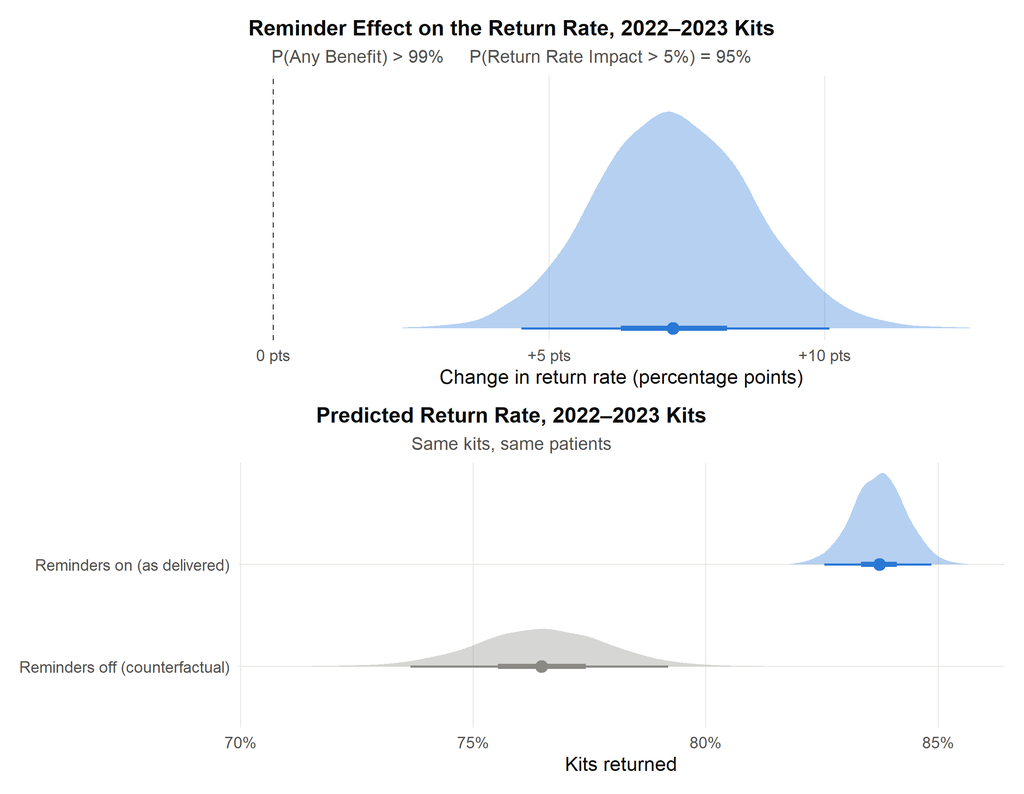

- Among 2022–2023 kits, the reminder program raised the return rate from an estimated **76.5%** to **83.7%**, a gain of **7.2 points, 95% CrI [4.5, 10.1]**.
- At the clinic’s 2022–2023 volume of about 1,280 kits a year, that works out to about 93 more completed screening tests each year, 95% CrI [58, 129].
- On the odds scale, reminders raised the odds of a return during days 15–90: **OR = 2.12, 95% CrI [1.46, 3.21]**.
- Other changes after 2022 had no clear effect (OR = 1.01, 95% CrI [0.76, 1.34]). Once time trends, COVID and season are in the model, the rise in returns is credited to the reminders.

An important caveat here is that returns after day 90, once texts had stopped, also rose. The post-period odds of a very late return were higher than before 2022 (OR = 2.93, 95% CrI [1.89, 4.60]). This could be patients acting on the final texts a few days after day 90, or another post-2022 change that only touched very late returns, and these data cannot tell the two apart. I counted it as part of the reminder effect. Only 991 of 4,302 kits were still out at day 90, but this term may still account for a meaningful share of the gain, so splitting the effect by window is first on my list of next steps.

## 5.2 Text-Consent Placebo Check

Did patients who never received texts improve too?

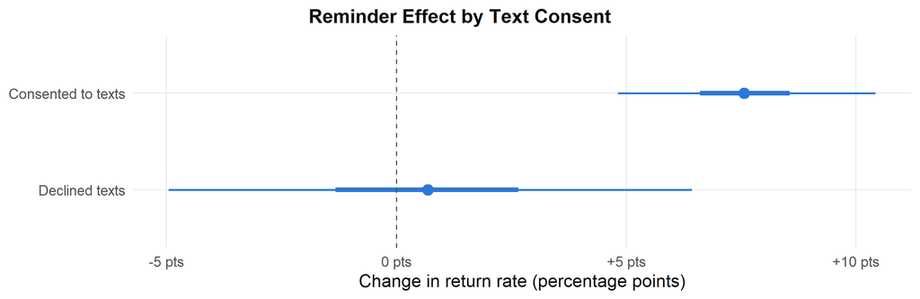

Patients who declined texts should not have received reminders, so their true reminder effect should be 0. The model leaves this for the data to show. Their post-period kits pass through windows 2 and 3 like every other kit:

- In days 15–90, their effect is $R_i = \beta_{\text{remind}} + (\text{subgroup terms}) + \gamma_{\text{con,No}}$.
- After day 90, it is $C_i = \beta_{\text{carry}} + \gamma_{\text{carry,con,No}}$.

The 2 consent terms are estimated freely, with no pull toward the other groups. If the decliners’ returns had risen as much as the consenters’, both terms would sit near 0. On the log-odds scale:

- **Days 15–90:** the decliners’ effect is $\beta_{\text{remind}} + \gamma_{\text{con,No}}$ = -0.03, 95% CrI [-0.89, 0.82], versus $\beta_{\text{remind}}$ = 0.75, 95% CrI [0.38, 1.17] for consenters.
- **After day 90:** the decliners’ carry-over is $\beta_{\text{carry}} + \gamma_{\text{carry,con,No}}$ = 0.36, 95% CrI [-0.83, 1.48], versus $\beta_{\text{carry}}$ = 1.07, 95% CrI [0.64, 1.53] for consenters.

On the percentage-point scale:

- Declined texts: **0.7 points, 95% CrI [-5.0, 6.4]**
- Consented: 7.6 points, 95% CrI [4.8, 10.4]
- Probability that consenters gained more: 99%

The decliner group is small (117 post-period kits, few of them still out at day 90), so the intervals are wide. Still, the gap points the way the reminders predict, which is a good sign.

**Why decliners have their own after-day-90 term.** My first three-window version applied the after-day-90 change to every post-period kit, decliners included. That made decliners appear to gain 3.1 points from texts they never received. Giving them their own term let the data speak for that group, and their estimated gain dropped to the value above.

> **Author note:** confirm with the clinic that patients who declined texts received no reminders by any other route.

## 5.3 Reminder Effects by Subgroup

Did reminders work better for some patients than others?

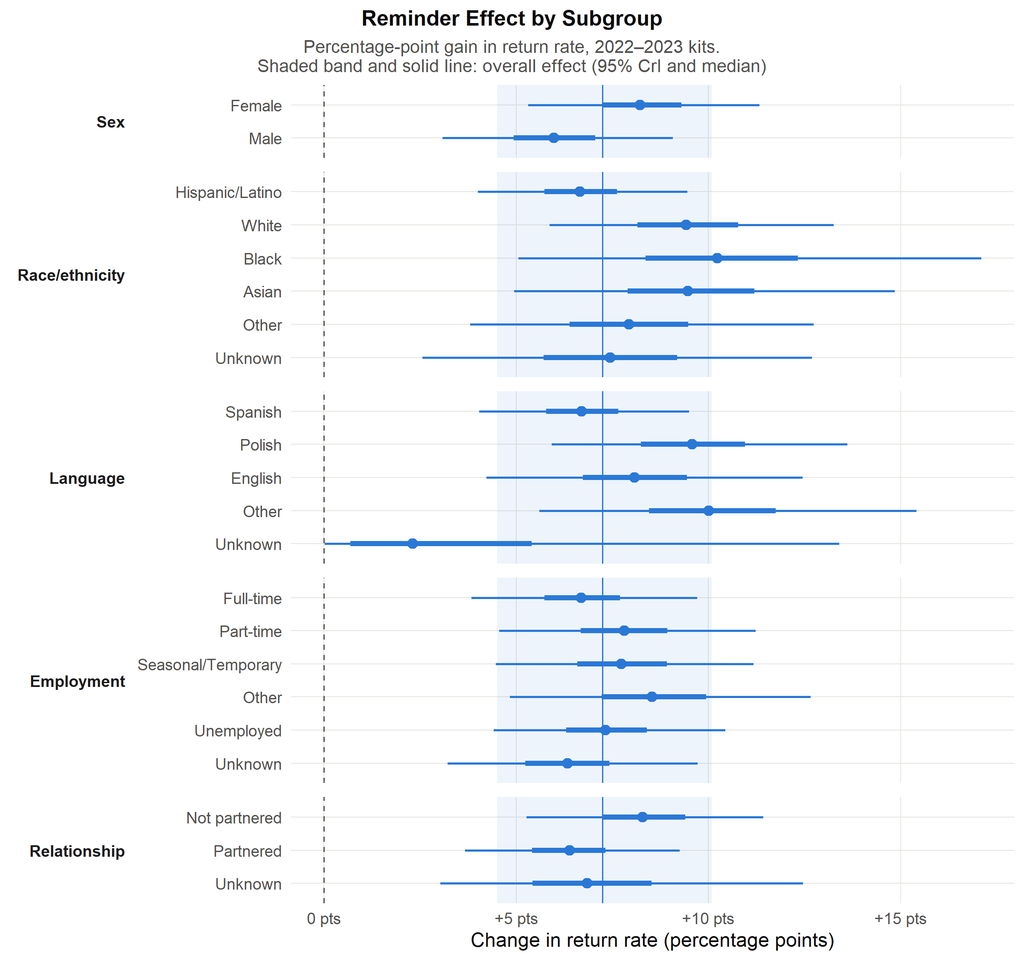

**What the plot shows.**

- Each row is the **total reminder effect for kits in that subgroup**, in percentage points: the predicted return rate with reminders minus without, averaged over the subgroup’s 2022–2023 kits.
- Each row combines the average effect ($\beta_{\text{remind}}$), that group’s deviation (its $\delta$, i.e. the reminder × subgroup interaction), and the other characteristics of the patients in the group.
- The interaction terms themselves are in the appendix (Subgroup Deviations). Because reminders only act in window 2 of post-period kits, each $\delta$ is a 3-way interaction: *post-2022 × days 15–90 × subgroup*.

**What it says.**

- **Sex.** Women gained 8.2 points, 95% CrI [5.3, 11.3]; men gained 6.0 points, 95% CrI [3.1, 9.1]. The probability that women benefited more is 98%.
- **Age.** On the log-odds scale, the reminder effect changes per decade of age by $\gamma_{\text{age}}$ = 0.20, 95% CrI [-0.01, 0.43]. The probability that it grows with age is 97%.
- **Race/ethnicity, language, employment and relationship.** The differences are small, and every interval overlaps the overall effect. The model pulls these groups toward the overall estimate unless the data show a clear difference, and here they do not.
- **Reading percentage points across groups.** The same relative effect produces a larger percentage-point gain when a group’s starting return rate is lower.
  - Polish-speaking patients gained 9.6 points and Spanish-speaking patients 6.7. Most of that gap comes from the Polish group’s lower baseline; its log-odds deviation is close to 0 (see appendix).
  - Patients whose language had no matching text version (“Other”) still gained 10.0 points.
  - As such, the data do not show that language-matched messages drove the effect.

## 5.4 Other Predictors of Return

Which patients return kits, regardless of reminders?

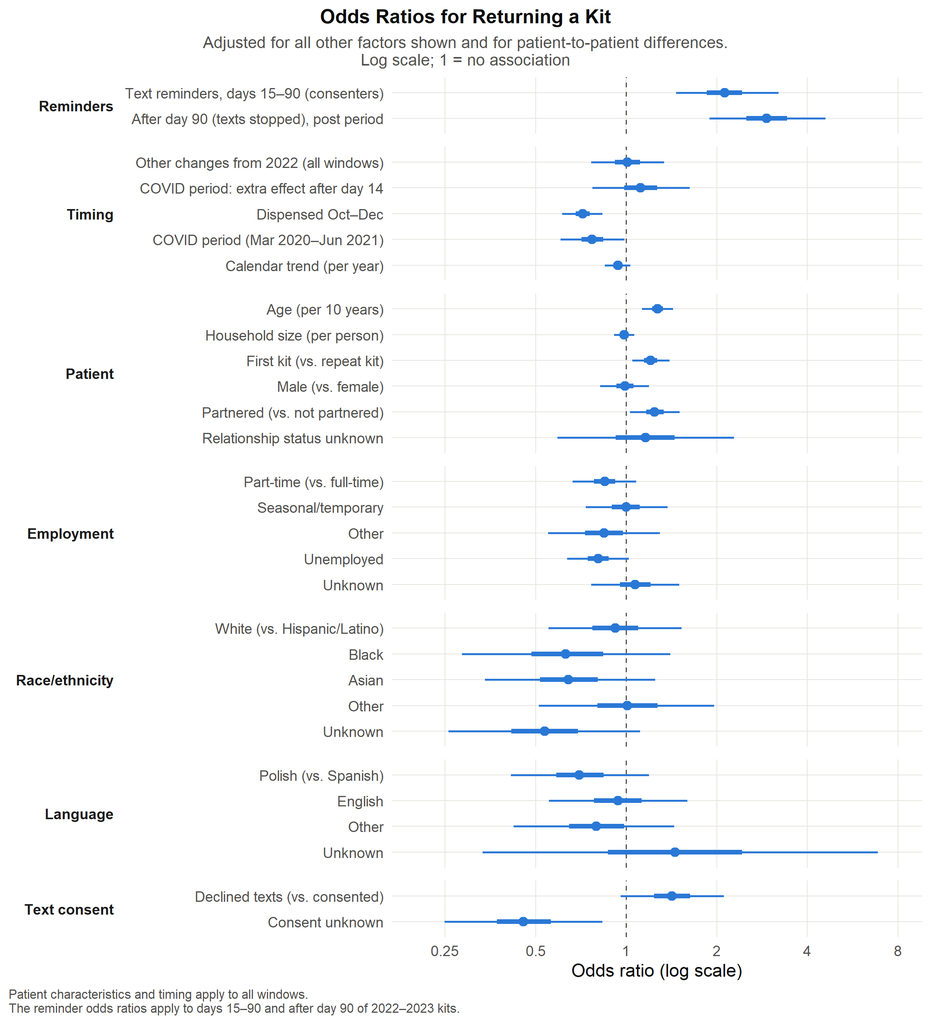

These odds ratios describe who returns kits, with or without reminders. Each one is adjusted for the others and for the patient’s own tendency to return.

- **Timing.**
  - Kits dispensed in October–December were less likely to be returned (OR = 0.72, 95% CrI [0.61, 0.83]).
  - So were kits dispensed during the COVID period (OR = 0.77, 95% CrI [0.61, 0.99]).
  - Plausible reasons for the Oct–Dec dip include holidays and travel, winter mail delays, and year-end outreach pushes that reach less-engaged patients. These data cannot tell them apart. The Seasonal Term check covers why I included it.
- **Age.** Older patients were more likely to return kits (OR per decade = 1.27, 95% CrI [1.13, 1.43]).
- **Relationship.** Partnered patients were more likely to return kits (OR = 1.24, 95% CrI [1.03, 1.51]).
- **Sex.** Sex had no clear link to the baseline return rate (OR for men = 0.99, 95% CrI [0.82, 1.19]). Differences by sex in the *response to reminders* are in Reminder Effects by Subgroup.
- **Race/ethnicity and language.** The intervals are wide because most groups are small, and none is clearly different from the reference group.
- **These are conditional (patient-specific) odds ratios.** They compare kits from patients with the same patient effect. Population-averaged odds ratios, which compare groups as a whole, are smaller in magnitude because patients differ so much (see below).

## 5.5 Patient Random Effects

How much do patients differ in their tendency to return kits, beyond what their recorded characteristics explain?

Each patient has 2 random effects:

- a tendency to return kits **promptly** (window 1)
- a tendency to return them **later** (windows 2–3)

A value of 0 means “typical for someone with these characteristics”. Positive values mean more likely to return, and negative values less likely, on the log-odds scale.

**How large are the differences between patients?**

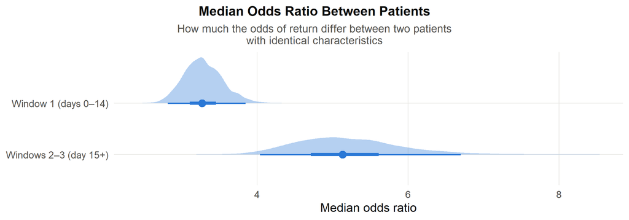

- The **median odds ratio** compares 2 randomly chosen patients with identical recorded characteristics.
- For returns after day 14, MOR = 5.1, 95% CrI [4.0, 6.7]. A typical pair of otherwise identical patients differs about 5-fold in their odds of returning a kit.
- That is larger than any covariate effect in Other Predictors of Return. It is also why ignoring repeated kits from the same patient, as a chi-square test or the original model does, understates uncertainty.
- A patient’s prompt and later tendencies are positively correlated ($\rho$ = 0.61, 95% CrI [0.46, 0.75]). Prompt returners also tend to be eventual returners, though the two tendencies are distinct.

**All 2,092 patients**

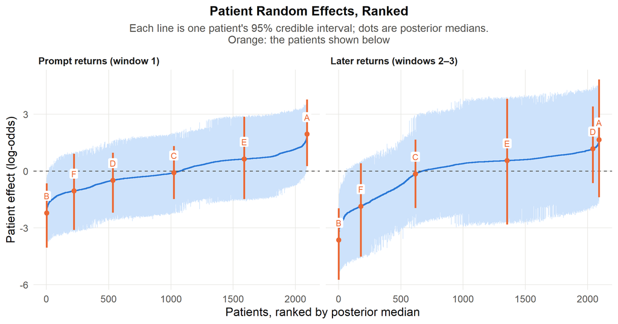

Most intervals are wide and overlap 0, because most patients contributed only 1 or 2 kits. The model pulls those patients toward the average (shrinkage) and only moves a patient far from 0 when they have a consistent record across several kits, which is a good sign.

**Selected patients**

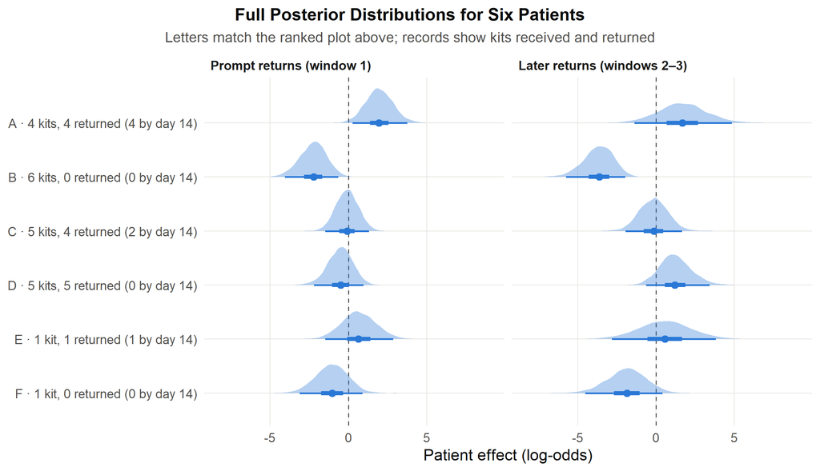

I picked these 6 patients to show the range of patient effects, and how the amount of data changes the estimate. Patient identifiers are left out.

- **A** (4 kits, 4 returned (4 by day 14)). Strongly positive: returned every kit, mostly within 14 days.
- **B** (6 kits, 0 returned (0 by day 14)). Strongly negative: returned few or none of several kits.
- **C** (5 kits, 4 returned (2 by day 14)). Near neutral, with plenty of data: a typical patient, estimated precisely.
- **D** (5 kits, 5 returned (0 by day 14)). Needs a nudge: slow to return early, but reliably returns later.
- **E** (1 kit, 1 returned (1 by day 14)). One kit, returned by day 14: little information, so the estimate stays near zero (shrinkage).
- **F** (1 kit, 0 returned (0 by day 14)). One kit, never returned: also shrunk toward zero, with a wide interval.

**Do patient effects absorb demographic effects?**

- The demographics are fixed effects ($\boldsymbol\beta$), and the patient effects are centred at 0 *given* those demographics. The patient effects only capture what is left over after age, sex, language and the other characteristics.
- The model does assume this leftover is unrelated to the demographics. If an unmeasured trait such as health literacy differs between language groups, part of it will show up in the language coefficients.
- As such, I read the demographic odds ratios as adjusted associations, and would not treat them as causal effects.
- The reminder effect is protected from this. It is estimated from how returns changed within each window after 2022, which does not depend on comparing demographic groups.

# 6 Model Checking

## 6.1 Convergence

Did the sampler explore the posterior properly?

I fitted the model with Stan (4 chains, 6,000 post-warmup draws in total). Standard diagnostics show no sign of sampling problems:

- **Divergent transitions:** 0 (target: 0).
- **R-hat** (agreement between chains): maximum 1.005 across 64 parameters (target: below 1.01).
- **Effective sample size:** minimum bulk ESS 556, minimum tail ESS 1014 (target: above 400). The lowest value is for rho_u.

Trace plots for key parameters are in the appendix.

**Computation time.** The 4 chains ran in parallel and took 6.8 minutes in total (per chain: 4.1, 4.3, 5.4, 6.8 minutes, including warmup). The model includes 4,184 patient effects.

## 6.2 Seasonal Term

Why is there an Oct–Dec term, and does the reminder effect depend on it?

I added the term after the EDA, which showed a sharp drop in returns for kits dispensed in late 2023. Short follow-up did not explain it, since every kit had at least 5 months to come back. Q4 was low in 2019, 2020 and 2023, but not in 2021 or 2022, so the evidence for a true seasonal effect is mixed. Because I chose the term after seeing the outcome data, I refit the model without it and compared the two.

**The reminder results do not change.**

- Reminder effect (points): 7.25, 95% CrI [4.50, 10.09] with the term; 7.37, 95% CrI [4.64, 10.22] without it.
- Patients who declined texts (points): 0.68, 95% CrI [-4.95, 6.43] with the term; 0.67, 95% CrI [-4.97, 6.71] without it.
- Women minus men (points): 2.26, 95% CrI [0.07, 4.48] with the term; 2.29, 95% CrI [0.08, 4.58] without it.

**The time terms do shift.** Without the Oct–Dec term, the low Q4 quarters (mainly late 2023) are absorbed elsewhere:

As such, I kept the Oct–Dec term. Dropping it leaves the reminder conclusions unchanged and distorts the time terms. The claim that nothing besides the reminders changed after 2022 does depend on it, since that odds ratio rises without the term (its interval still includes 1).

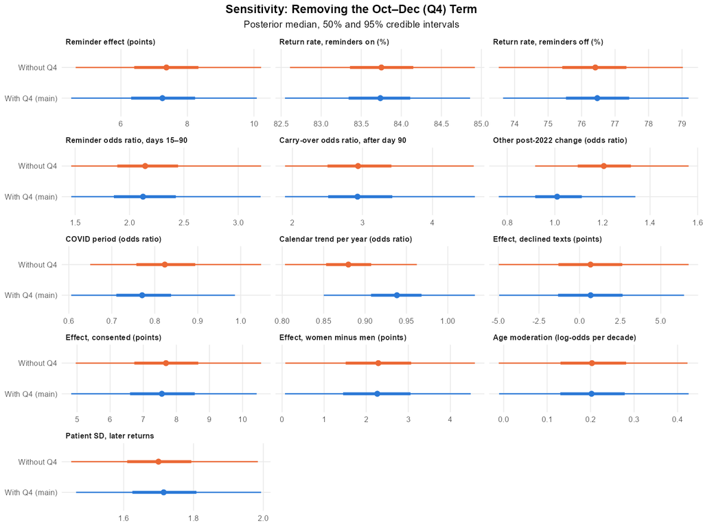

## 6.3 Posterior Predictive Check

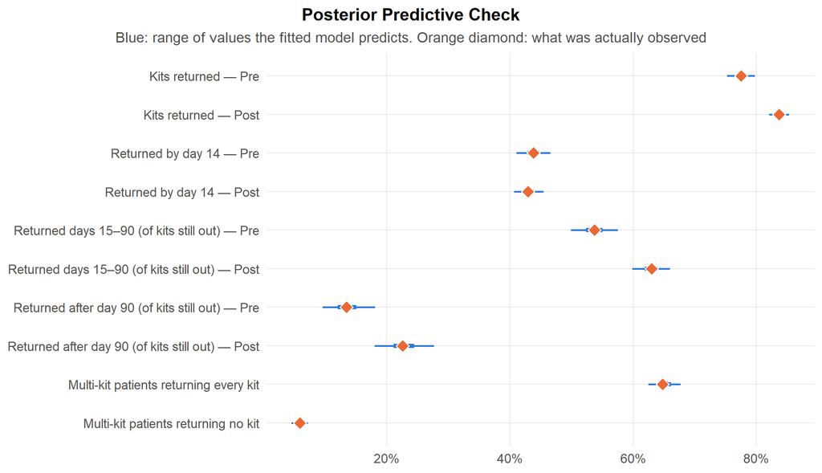

Can the fitted model reproduce the data it was fit to?

- I simulated new datasets from the fitted model and compared them with what was observed.
- If the model describes the data well, the observed values (orange) should fall inside the predicted ranges (blue).
- They do for every statistic checked, including the share of patients who return **all** or **none** of their kits.
- That last row matters most. A model without patient effects is unlikely to reproduce this all-or-none pattern.

## 6.4 Prior Predictive Check

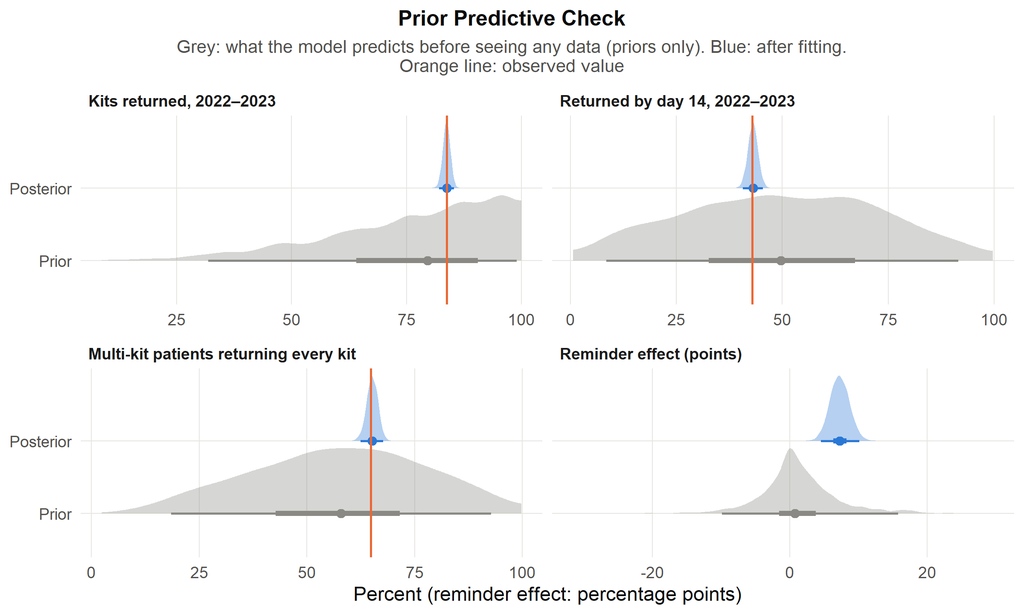

What did the model believe before seeing any data?

I ran the same model with the data switched off, so its predictions come from the priors alone. A good prior allows every plausible result, including the one actually observed, and leans toward no particular answer.

- **Return rates.**
  - Before seeing data, the model considers post-period return rates from 32% to 99% plausible (95% range). The observed 83.7% falls inside.
  - The prior leans toward high overall return rates (median 80%), because each kit gets 3 windows in which to be returned. The return rate for any single window (e.g. by day 14) is centred near 50%.
  - The data quickly override this lean.
- **All-or-none patients.** The priors already expect many multi-kit patients to return every kit or none, because they allow large patient differences ($\sigma_u$ up to about 4). The observed share sits inside this range, so the prior and the data agree.
- **Reminder effect.**
  - Before seeing data, the reminder effect is centred on 0, with a 95% range of -10 to +16 points. The prior allows reminders to help, harm or do nothing.
  - After fitting, the effect is concentrated at 7.2 points, so the conclusion comes from the data.

## 6.5 Prior vs. Posterior

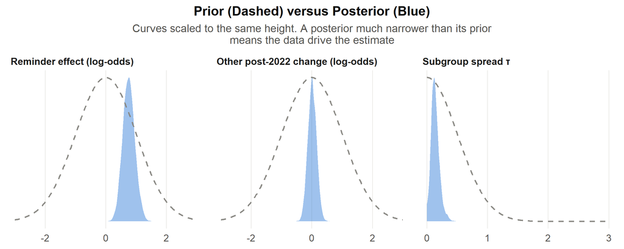

- For the reminder effect and the post-2022 change, the posteriors are far narrower than the priors, so these results come from the data.
- The subgroup spread τ is informed by the data but stays close to 0, which is why subgroup estimates are pulled toward the overall effect.

# 7 Limitations and Next Steps

**Limitations**

- **Observational design.** There is no randomised control group. The window comparison and the consent placebo strengthen the causal reading, but both rest on the assumption stated in Three-Window Design.
- **Cohort definition.** Patients were identified through FIT orders between November 2021 and November 2023. As such, pre-period kits only come from patients who were still with the clinic in the reminder era.
- **Exposure.** Individual text delivery was not recorded. I assumed that consenting patients with a post-period kit still out at day 14 received reminders until they returned it or day 90.
- **Small subgroups.** Several race/ethnicity and language groups have fewer than 50 patients, so their estimates are uncertain.
- **Shared later-return effect.** Windows 2 and 3 share one patient effect, because few kits reach window 3. This assumes a patient’s tendency to return during days 15–90 carries over to after day 90.

**Pending analyses** *(update this list as analyses are completed)*

- Pre-period placebo test: a fake reminder start in 2021 should show no effect (checks the key assumption)
- Prior sensitivity: refit with wider and narrower priors
- Frequentist cross-check (generalized linear mixed model with the same structure)
- Sensitivity: guideline-eligible ages only (50–75 before May 2021, 45–75 after)
- Sensitivity: exclude Oct–Dec 2023
- Sensitivity: patients with kits in both periods only

**Candidate model extensions**

- Split the overall reminder effect into its days 15–90 and after-day-90 parts (percentage points)
- Reminder effect changing over the post period (e.g. 2022 vs. 2023)
- Reminder effect for first vs. repeat kits
- Cohort-composition term (each patient’s share of post-period kits), so the post-2022 change is estimated within patients
- Window-specific covariate effects (e.g. employment may affect prompt returns more than later ones)

**Overall**, I am satisfied with this model. It answers each reviewer concern directly, its diagnostics and predictive checks pass, and the placebo check points the right way. If given more time, I would want to first run the pre-period placebo test, since the main estimate leans on its assumption, and then split the reminder effect by window to see how much of the gain comes after the texts stop.

# 8 Appendix

## 8.1 Subgroup Deviations

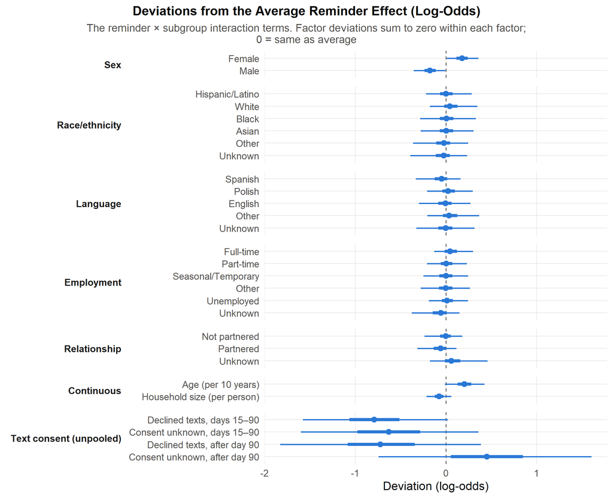

## 8.2 Trace Plots

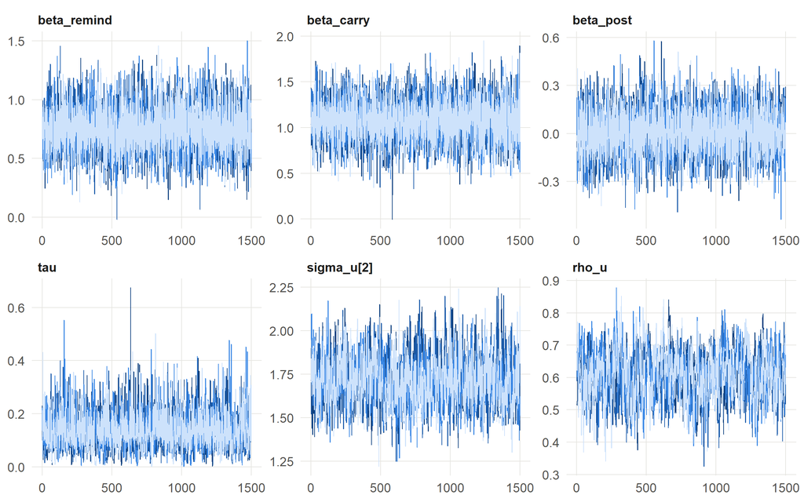

## 8.3 Stan Code

```
// =============================================================================
// kit_returns_stage.stan
//
// Three-window (discrete-time) hierarchical logistic model for FIT kit returns.
//
// Reminder schedule (post period, 2022+): a text every 2 weeks from day 14 to
// day 90 after the kit was sent, stopping early if the kit is returned. Each kit
// therefore passes through three windows:
//   Window 1 (days 0-14):  returned by day 14?                 no reminders yet
//   Window 2 (days 15-90): returned, given still out at day 14? reminders active
//   Window 3 (day 91+):    returned, given still out at day 90? reminders stopped
//
//   P(kit returned) = p1 + (1 - p1) p2 + (1 - p1)(1 - p2) p3
//
// The reminder effect R_i enters window 2 of post-period kits. Window 3 gets a
// separate post-period "carry-over" term C_i (late responses to the last texts,
// or a changed pool of kits still out at day 90); like R_i, it has its own
// unshrunk terms for patients who declined texts. Changes after 2022 that are not
// reminders (beta_post) act on all windows and are identified mainly from
// window 1. Identifying assumption: absent reminders, post-2022 changes would
// have shifted returns in every window equally on the log-odds scale.
//
// Patients get correlated random intercepts: one for prompt returns (window 1)
// and one for later returns (windows 2 and 3 share it).
//
// Reminder-effect heterogeneity: sum-to-zero deviations by sex, race/ethnicity,
// language, employment and relationship, all sharing one learned shrinkage
// scale tau; linear moderation by age and family size; unshrunk terms for text
// consent (non-consenting patients presumably got no texts -> placebo check).
//
// prior_only = 1 skips the likelihood, giving draws from the prior (for prior
// predictive checks).
// =============================================================================

functions {
  // Linear predictors for every kit. Columns 1-3 = window 1-3 logits under the
  // regime the kit actually had; column 4 = that kit's reminder effect R_i
  // (window 2); column 5 = its carry-over effect C_i (window 3).
  matrix linear_predictors(vector alpha, vector beta, real beta_post,
                           real beta_covid_late, real beta_remind, real beta_carry,
```

[output cut: 293 more lines]

```

    {
      real all_ret = 0;
      real none_ret = 0;
      for (j in 1:J) {
        if (n_kits_pat[j] >= 2) {
          all_ret  += ret_pat[j] == n_kits_pat[j];
          none_ret += ret_pat[j] == 0;
        }
      }
      rep_all_multi  = all_ret / n_multi;
      rep_none_multi = none_ret / n_multi;
    }
  }
}
```

## 8.4 Reproducibility

```
Model output: 03_output/models/stage_model
Prior-only output: 03_output/models/stage_model_prior
CmdStan: 2.36.0
R: 4.4.2
Fit script: 02_scripts/03_fit_stage_model.R
Report rendered: 2026-11-23 11:28
```